# Medicare Bundled Payment Policy on Anemia Care, Major Adverse Cardiovascular Events, and Mortality among Adults Undergoing Hemodialysis | American Society of Nephrology

Original ArticleMaintenance Dialysis

Open Access

# Medicare Bundled Payment Policy on Anemia Care, Major Adverse Cardiovascular Events, and Mortality among Adults Undergoing Hemodialysis

Haesuk Park, Raj Desai, Xinyue Liu, Steven M. Smith, Juan Hincapie-Castillo, Linda Henry, Amie Goodin, Saraswathi Gopal, Carl J. Pepine and Raj Mohandas

CJASN June 2022, 17 (6) 851-860; DOI: https://doi.org/10.2215/CJN.14361121

## Visual Abstract

[figure not shown]

## Abstract

**Background and objectives** In 2011, the Centers for Medicare & Medicaid Services implemented bundling of all services for patients receiving dialysis, including erythropoietin-stimulating agents use, and the Food and Drug Administration recommended conservative erythropoietin-stimulating agent dosing.

**Design, setting, participants, & measurements** This retrospective cohort study investigated anemia care and clinical outcomes before and after the Centers for Medicare & Medicaid Services bundled payment and the revised Food and Drug Administration–recommended erythropoietin-stimulating agent labeling for Medicare-insured adults receiving hemodialysis using data from the United States Renal Data System from January 1, 2006 to December 31, 2016. Clinical outcomes included major adverse cardiovascular event (stroke, acute myocardial infarction, and all-cause mortality), cardiovascular mortality, and heart failure. Measurements were compared between prepolicy (2006–2010) and postpolicy (2012–2016) implementation using interrupted time series and Cox proportional hazards regression models.

**Results** Of 481,564 patients, erythropoietin-stimulating agent use immediately decreased by 84.8 per 1000 persons (*P*<0.001), with a significant decrease in the slope of the trend line (both *P*=0.001). Blood transfusion use rapidly increased by 8.34 per 1000 persons in April 2012 and then gradually decreased (both *P*=0.001). The percentage of patients with hemoglobin >11 g/dl decreased from 68% in January 2006 to 28% in December 2016, whereas those with hemoglobin <9 g/dl increased from 5% to 9%. Overall major adverse cardiovascular event (adjusted hazard ratio, 0.95; 95% confidence interval, 0.94 to 0.96), stroke (adjusted hazard ratio, 0.83; 95% confidence interval, 0.80 to 0.86), all-cause mortality (adjusted hazard ratio, 0.87; 95% confidence interval, 0.86 to 0.89), cardiovascular mortality (adjusted hazard ratio, 0.81; 95% confidence interval, 0.79 to 0.83), and heart failure (adjusted hazard ratio, 0.86; 95% confidence interval, 0.84 to 0.88) risks were lower. Acute myocardial infarction risk (adjusted hazard ratio, 1.04; 95% confidence interval, 1.01 to 1.06) was higher after policies changed.

**Conclusions** The Medicare reimbursement policy and Food and Drug Administration–recommended erythropoietin-stimulating agent dosing changes were associated with lower erythropoietin-stimulating agent use and lower hemoglobin levels. These changes in anemia care were associated with lower risks of major adverse cardiovascular event, stroke, mortality, and heart failure but higher risk of acute myocardial infarction among adults receiving hemodialysis.

- hemodialysis
- anemia
- [Medicare bundled payment](https://cjasn.asnjournals.org/keyword/medicare-bundled-payment)
- [erythropoietin-stimulating agents](https://cjasn.asnjournals.org/keyword/erythropoietin-stimulating-agents)
- [major adverse cardiovascular event](https://cjasn.asnjournals.org/keyword/major-adverse-cardiovascular-event)
- hemoglobin

## Introduction

Medicare has been the primary payer for kidney failure care in the United States since 1972, when Medicare instituted coverage for all patients with kidney failure. Medicare spending on dialysis care underwent enormous growth during the last two decades under a fee-for-service system, driven largely by the rapidly increasing use of erythropoietin-stimulating agents (ESAs). Until recently, ESAs were considered standard therapy to increase hemoglobin levels in patients with CKD and anemia (1⇓⇓–4).

In the mid-2000s, extensive use of ESAs was questioned owing to reports of higher cardiovascular risk that appeared to be associated with ESA-induced increased hemoglobin levels (5⇓⇓⇓–9). In particular, the Correction of Hemoglobin and Outcomes in Renal Insufficiency trial (2006) (7), the Cardiovascular Risk Reduction by Early Anemia Treatment with Epoetin Beta trial (2006) (9), and the Trial to Reduced Cardiovascular Events with Aranesp Therapy (2009) (5) demonstrated that patients with CKD randomized to receive ESAs for a higher target hemoglobin concentration experienced a higher risk of stroke, cardiovascular events, and mortality than those randomized to a lower hemoglobin target. As a result, in 2007, a “black box warning” was issued by the US Food and Drug Administration (FDA) to use the lowest possible ESA doses for anemia treatment associated with CKD (10). On June 24, 2011, the FDA warned against ESA use for increasing hemoglobin levels >10 g/dl, suggesting instead the use of maintenance doses between 9 and 10 mg/dl, and it advised weighing the benefits of using ESAs against possible harms, including a need for blood transfusion (11).

In addition to these regulatory changes, on January 1, 2011, the Centers for Medicare & Medicaid Services (CMS) implemented a new fully bundled prospective payment system (PPS) for services provided by dialysis facilities to patients with kidney failure (12). Under the PPS, payment bundling was expanded to encompass services previously reimbursed independently, notably injectable medications (*e.g*., ESA and intravenous iron) and laboratory tests, in addition to items previously included in the composite rate. On January 1, 2012, PPS expanded further to include a provision for improving the quality of anemia care through the Quality Incentive Program, in which CMS imposed a maximum payment reduction of 2% as a result of poor performance. This reimbursement policy shift was one of the most significant in the history of the ESRD program (13). Given that the effect of the policy changes on clinical outcomes may not occur immediately after policy implementation, we investigated the long-term effects of these Medicare reimbursement policy and FDA regulation changes on anemia care and clinical outcomes among patients with kidney failure receiving hemodialysis.

## Materials and Methods

### Data Source

We conducted a retrospective cohort study using national kidney failure registry data from the United States Renal Data System (USRDS) from January 1, 2006 to December 31, 2016 for Medicare-eligible patients receiving dialysis. USRDS is a national registry of patients with kidney failure on the basis of Medicare claims submitted to CMS. This database has near-universal inclusion of patients with kidney failure in the United States and includes Medicare enrollment history, Medicare Parts A and B claims, and death dates. Institutional review board approval for this study was obtained from the University of Florida.

### Study Outcomes and Design

#### Anemia Care.

Anemia care outcomes included use of an ESA (darbepoetin alfa, epoetin alfa, and epoetin beta) or intravenous iron or receipt of a blood transfusion to maintain hemoglobin levels. ESA therapy was identified using the Healthcare Common Procedure Coding System (HCPCS) for inpatient and outpatient settings. Receipt of intravenous iron was also identified using HCPCS codes. Blood transfusion was identified using *Clinical Procedural Terminology* codes, HCPCS codes, or *International Statistical Classification of Diseases*, *Ninth Revision*/*Tenth Revision* (*ICD-9/10*) procedure codes ([Supplemental Table 1](http://cjasn.asnjournals.org/lookup/suppl/doi:10.2215/CJN.14361121/-/DCSupplemental) shows the complete list of codes). The number of patients with one or more claims of ESA, intravenous iron, or blood transfusion and person-months were determined for each month and subsequently used to calculate the use of anemia treatments per 1000 person-months. For each month, we also determined monthly ESA dose and monthly hemoglobin concentration. Only epoetin alfa was used when describing trends of ESA use. To describe changes in anemia management before and after January 2012, we used an interrupted time series analysis to evaluate longitudinal effects of the interventions while accounting for preintervention trends (14,15).

#### Clinical Outcomes.

We used *ICD-9/10* diagnosis codes to evaluate the risk of (*1*) MACE, including stroke, acute myocardial infarction, and all-cause mortality; (*2*) cardiovascular mortality; and (*3*) hospitalized heart failure. Cardiovascular mortality was defined as death associated with arrhythmias, cardiac arrest, congestive heart failure, acute myocardial infarction, or atherosclerotic heart disease (16). Follow-up began on day 91 after hemodialysis initiation, and patients were censored if they underwent a kidney transplantation, had a change in dialysis modality (*e.g*., switched to peritoneal dialysis or home hemodialysis), discontinued Medicare coverage, reached the administrative end of follow-up (December 31, 2010 for the prepolicy cohort; December 31, 2016 for the postpolicy cohort), or experienced an outcome, whichever occurred first.

### Covariates

We ascertained pertinent patient characteristics (*e.g*., age, sex, race/ethnicity, and geographic region) from the USRDS patient file and serum albumin level, body mass index (kilograms per meter squared), baseline hemoglobin concentration (grams per deciliter), tobacco use, primary reason for kidney failure, and comorbidities from the Medical Evidence Report at the time of dialysis initiation. Comorbidities included atherosclerotic heart disease, hypertension, heart failure, cerebrovascular disease, peripheral artery disease, cancer, chronic obstructive pulmonary disease, and diabetes mellitus. The type of vascular access (arteriovenous fistula or arteriovenous graft) was also included.

### Statistical Analyses

We summarized the characteristics of the patients in the incident hemodialysis cohort for the pre- and postpolicy periods. We then tabulated and plotted the receipt of each category of anemia treatment for patients in the incident hemodialysis cohort. We compared trends in anemia care for the periods between 2006–2011 and 2012–2016 using segmented linear regression, fitting generalized least squares linear models with an autoregressive-moving average correlation structure, which estimates two parameters—changes in level (value of the series at the beginning of the postpolicy period) and slope (rate of change of a measure during the postpolicy period) (14). To compare changes from 2006 to 2016 in the proportion of patients stratified by hemoglobin level (<9, 9–11, or >11 g/dl), we used the Cochran–Mantel–Haenszel test.

The differences in baseline covariates between the prepolicy and postpolicy periods were measured using standardized mean differences, with differences <0.1 considered well balanced (17). The incidence rates for first MACE were estimated as the number of events per 1000 person-years. Kaplan–Meier curves using the log-rank test were generated for the pre- and postpolicy periods. Cox proportional hazards regression models were used to estimate hazard ratios (HR) and 95% confidence intervals (95% CIs) to compare risk of MACE, all-cause mortality, heart failure, and blood transfusion between the pre- and postpolicy periods, controlling for covariates. For the Cox regression models, we included patients with hemoglobin levels ≤18 g/dl. The incidence rates and HRs were calculated at 1 year, 3 years, and the end of the cohort. We conducted a sensitivity analysis using the initiation date of hemodialysis as the index date instead of using day 91 as we did for the main analysis. All statistical analyses were two tailed, with an *a priori* significance level of *α* = 0.05. All analyses were conducted using SAS, version 9.4 (SAS Institute Inc., Cary, NC).

## Results

### Patient Characteristics

Table 1.

### Trends in Anemia Care

For the incident hemodialysis cohort, following implementation of PPS in 2011 and the Quality Incentive Program in January 2012, an immediate decrease was observed in the prevalence of ESA use (from 732 per 1000 persons in April 2006 to 672 per 1000 persons in December 2016; −84.8 per 1000 persons; *P*<0.001), and a significant decrease was observed in the slope of the trend line (−1.21 per 1000 person-months; *P*=0.001) (Figure 1A). An immediate decrease was also observed for the mean ESA dose, which continued to decrease from 81,743 international units in April 2006 to 38,124 international units in December 2016 (*P*<0.001) (Figure 1B). Use of intravenous iron supplementation was relatively stable, but after January 2012, there was an immediate increase in the prevalence of iron use (51.7 per 1000 person-months; *P*<0.001), with a significant decrease in the slope of the trend line (−1.09 per 1000 person-months; *P*<0.001) (Figure 1C). The proportion of patients receiving at least one blood transfusion increased immediately in January 2012 (8.3 per 1000 person-months; *P*<0.001), but thereafter, the receipt of blood transfusion gradually decreased (−0.26 per 1000 person-months; *P*<0.001) (Figure 1D).

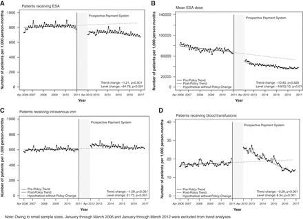

Figure 1.

**Trends in treatment with erythropoiesis-stimulating agent (ESAs), intravenous iron, and blood transfusion on patients on incident hemodialysis (per 1000 person-months) by month (2006–2016).** (A) Patients receiving ESAs. (B) Mean ESA dose. (C) Patients receiving intravenous iron. (D) Patients receiving blood transfusions.

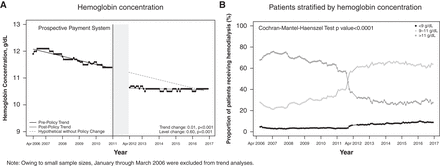

Figure 2.

**Trends in hemoglobin concentration in patients on incident hemodialysis (per 1000 person-months) by year (2006–2016).** (A) Hemoglobin concentration. (B) Patients stratified by hemoglobin concentration.

### Clinical Outcomes

Table 2.

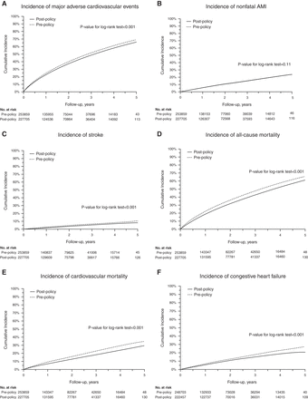

Figure 3.

**Unadjusted cumulative incidence rates before and after policy change among patients on incident hemodialysis.** (A) Incidence of major adverse cardiovascular events. (B) Incidence of nonfatal acute myocardial infarction (AMI). (C) Incidence of stroke. (D) Incidence of all-cause mortality. (E) Incidence of cardiovascular mortality. (F) Incidence of congestive heart failure.

## Discussion

This study used data from a national registry of patients receiving hemodialysis in the United States between 2006 and 2016 to provide changes in the patterns of anemia treatments and clinical outcomes for patients receiving hemodialysis. After changes to Medicare’s reimbursement policy for dialysis services and after the FDA-revised recommendations for ESA use became effective, we observed a significant decrease in ESA use and a corresponding immediate increase in blood transfusion use, although the use of blood transfusions trended downward thereafter. Despite this trend in blood product use, declining ESA use was associated with decreases in hemoglobin level, specifically a decrease in the proportion of patients with hemoglobin levels >11 g/dl and an increase in the proportions of patients with hemoglobin levels between 9 and 11 or <9 g/dl during our study period. The overall changes in anemia care were also associated with a downward trend in MACEs. This significant finding was further confirmed in our multivariable Cox regression model, with overall lower risks of MACE and cardiovascular mortality but a higher risk of nonfatal acute myocardial infarction in the era after the policy changes.

Our findings build on previous studies that reported initial evidence of temporal changes in anemia care and clinical outcomes up until 2012, but unlike prior studies, we noted that these results became more obvious and significant for a longer period of time than originally reported (18⇓⇓⇓⇓⇓–24). A recent study conducted by Chertow *et al.* (25) reported no changes in overall MACE, nonfatal acute myocardial infarction, or mortality in 2011–2012, although the observed rate of stroke was lower than expected. Similarly, Wang *et al.* (26) investigated MACE outcome among the incident cohort and suggested that the decreased use of ESAs in practice was not associated with either mortality or MACE while lowering stroke risk, despite the increased risk of blood transfusion events from July 2011 to June 2013. These differences in findings may be explained by different study populations, study designs, and follow-up times. Our study included patients on incident hemodialysis who became eligible for Medicare regardless of their age after a 90-day waiting period, enabling patients to stabilize on modality and to gain Medicare (*n*=481,564). By contrast, the previous study was limited to Medicare beneficiaries ≥66 years at initiation of hemodialysis (*n*=69,718) (26). Because approximately 60% of patients initiating dialysis are younger than 65 years and do not qualify for Medicare benefits within the first 90 days, our population is more generalizable than the previous study to patients receiving dialysis in the United States (27). We also incorporated a phase-in period in our analysis to account for potential delays in implementation of changes resulting from FDA guidance and CMS reimbursement policies. Significant trends were detected over the 5 years of follow-up in this study (versus up to 2 years of follow-up in the previous study). Most notably, changes in anemia treatment and lower associated risks began to emerge almost immediately after the changes in policies, and the risks continued to become lower over time. Thus, longitudinal follow-up is needed to determine the continuous effects of those changes.

The higher risk of nonfatal acute myocardial infarction may potentially be explained by the U-shaped relationship between hemoglobin concentration and acute myocardial infarction (28,29). Although the mechanisms underlying how low hemoglobin concentration is associated with a higher risk of acute myocardial infarction are not completely understood, several plausible mechanisms have been suggested. Lower levels of hemoglobin may induce myocardial ischemia from an imbalance between oxygen demand and supply (30). In addition, chronic anemia may result in increased cardiac output, which, over time, may lead to left ventricular hypertrophy and left ventricular dilation (29⇓⇓–32). However, we must acknowledge that the increase noted in acute myocardial infarctions in our study may be partially due to several other reasons. In January 2011, the number of secondary diagnoses that could be listed on the discharge record increased from nine to 24, resulting in an increase in the capture of acute myocardial infarctions rather than a true increase in the number of cases (33). In addition, patients with CKD may have chronically elevated troponin levels, which may result in an increased capture of acute myocardial infarction, particularly with the adoption of high-sensitivity troponins (34). However, we suspect these factors to be minimal or not present because a recent study found that the rate of acute myocardial infarction hospitalizations among Medicare recipients has decreased since 2011, and further inspection in our study demonstrated that acute myocardial infarction diagnosis occurrence on the basis of the presence of secondary diagnoses remained consistent (48% in the prepolicy period versus 50% in the postpolicy period; data not shown) (35).

Similar to prior studies, we observed a lower risk of stroke in the postpolicy period. Our findings are consistent with those of a randomized clinical trial in which a higher hemoglobin concentration target (13.5–14.5 g/dl) rather than a lower target (9.5–10.5 g/dl) was associated with higher risk of cerebrovascular events among patients on incident hemodialysis (9). A similar reduced stroke risk was also indicated by an observational study of patients on hemodialysis immediately after the policy change (26). Although the mechanisms linking hemoglobin levels (or lower ESA use) and the risk of stroke are not yet fully understood, our study results suggested that reduction in ESA use (and lower hemoglobin levels) in the postpolicy period was associated with a lower risk of stroke among patients receiving hemodialysis.

Our study has several limitations. First, our incident cohort was restricted to patients who survived 90 days after the initiation of dialysis and had Medicare as their primary payer at day 91. Because mortality in the initial 90 days of dialysis is known to be high (40), our findings of cardiovascular outcomes and mortality are only generalizable to those who survive the first 90 days. To address this limitation, we also conducted a sensitivity analysis that was not restricted to patients who survived the first 90 days and found that the results remain consistent with our main analysis. Second, USRDS records data for patients only after their first outpatient dialysis treatment. Thus, we did not capture the use of ESAs, intravenous iron supplementation, or blood transfusion prior to dialysis, which may have influenced outcomes. We did not include the ESA dose during hospitalizations, which might underestimate the mean ESA dose. It is possible that we underestimated comorbidities as the Medical Evidence Report undercodes comorbidities at the time of dialysis. Third, dialysis centers submit a single hemoglobin value to CMS each month for each patient receiving hemodialysis, which may not accurately represent the patient’s hemoglobin concentration over the entire month. Fourth, this study included Medicare beneficiaries undergoing hemodialysis. Thus, these results may not be generalizable to patients undergoing home or peritoneal dialysis covered by Medicaid or commercial insurance. Fifth, because this was an observational cohort analysis, we were unable to imply causal effects of the policy changes on MACE outcomes. The decreasing trends started in the mean ESA dose and hemoglobin levels, although the number of patients who received ESA increased during the prepolicy period. Considering the changes that occurred in clinical practice before the policy was implemented ([Supplemental Figure 2](http://cjasn.asnjournals.org/lookup/suppl/doi:10.2215/CJN.14361121/-/DCSupplemental)), we could not single out the extent of policy and regulatory effects on MACE outcomes. Although we adjusted for as many confounders as available, it is possible that unmeasured confounders might affect our findings. Finally, we relied on *ICD-9/10* codes to identify MACE outcomes. Although we used codes previously validated for such purposes, it is possible that incomplete, missing, or miscoded claims may have affected the study findings. Nevertheless, coding errors were likely to have been similarly distributed between the pre- and postpolicy periods, which would tend to bias estimates conservatively.

Following changes in Medicare’s reimbursement policy and the FDA’s recommendation for conservative ESA dosing, we observed a significant decrease in ESA use and in hemoglobin levels but a transient increase in blood transfusions that decreased over time. These changes were associated with a significantly lower risk of overall MACE, stroke, and cardiovascular mortality, as well as of all-cause mortality, but a higher risk of acute myocardial infarction in the 5-year follow-up period. These findings suggest that longitudinal follow-up is necessary to continually assess the outcomes of policy changes to determine if further refinement may be necessary.

## Disclosures

J. Hincapie-Castillo reports research funding from Merck. X. Liu is a current full-time employee at Merck & Co; this work was conducted when she was affiliated with the University of Florida. X. Liu reports ownership interest in Merck & Co. H. Park reports research funding from the Bristol-Myers Squibb/Pfizer Alliance American Thrombosis Investigator Initiated Research Program. C.J. Pepine reports consultancy agreements with Caladrius Biosciences, SLACK Inc., and XyloCor; research funding from Biocardia, Brigham and Women's Hospital, CSL Behring, Cytori Therapeutics, DCRI, Department of Defense, GE Healthcare, Mesoblast, National Institutes of Health/National Heart, Lung, and Blood Institute, National Institutes of Health/National Institute on Aging, and Pfizer; and serving as Editor-in-Chief of *AHA Plus*. S.M. Smith reports serving in an advisory or leadership role with the Consortium for Southeastern Healthcare Quality (unpaid). All remaining authors have nothing to disclose.

## Funding

Research reported in this publication was supported in part by National Institute on Drug Abuse of the National Institutes of Health grant K01DA045618 (to H. Park).

## Acknowledgments

The National Institute on Drug Abuse of the National Institutes of Health played no role in the design and conduct of the study; collection, management, analysis, and interpretation of the data; preparation, review, or approval of the manuscript; and decision to submit the manuscript for publication.

## Author Contributions

H. Park, R. Desai, S.M. Smith, and R. Mohandas conceptualized the study; R. Desai, J. Hincapie-Castillo, X. Liu, H. Park, and S.M. Smith were responsible for data curation; H. Park was responsible for investigation; R. Desai, J. Hincapie-Castillo, X. Liu, H. Park, and S.M. Smith were responsible for formal analysis; H. Park was responsible for methodology; R. Desai, A. Goodin, L. Henry, J. Hincapie-Castillo, X. Liu, and H. Park were responsible for project administration; H. Park was responsible for funding acquisition; H. Park wrote the original draft; and R. Desai, A. Goodin, S. Gopal, L. Henry, J. Hincapie-Castillo, X. Liu, R. Mohandas, H. Park, C.J. Pepine, and S.M. Smith reviewed and edited the manuscript.

## Supplemental Material

This article contains the following supplemental material online at http://cjasn.asnjournals.org/lookup/suppl/doi:10.2215/CJN.14361121/-/DCSupplemental.

[Supplemental Figure 1](http://cjasn.asnjournals.org/lookup/suppl/doi:10.2215/CJN.14361121/-/DCSupplemental). Flow chart of the cohort creation.

[Supplemental Figure 2](http://cjasn.asnjournals.org/lookup/suppl/doi:10.2215/CJN.14361121/-/DCSupplemental). Adjusted incidence rate of MACE by cohort entrance quarterly (2006–2015) among patients on incident hemodialysis.

[Supplemental Table 1](http://cjasn.asnjournals.org/lookup/suppl/doi:10.2215/CJN.14361121/-/DCSupplemental). Codes used to identify claims of ESA, intravenous iron, and blood transfusion.

[Supplemental Table 2](http://cjasn.asnjournals.org/lookup/suppl/doi:10.2215/CJN.14361121/-/DCSupplemental). Risk for major adverse cardiovascular event, mortality, heart failure, and blood transfusion before and after bundle policy changes among patients on incident hemodialysis in sensitivity analysis using the initiation date of hemodialysis as index date.

## Footnotes

- Published online ahead of print. Publication date available at [www.cjasn.org](http://www.cjasn.org/).
- See related Patient Voice, “Medicare Bundled Payment Policy and Anemia Care: Perspectives from a Patient with Kidney Disease,” on pages [769–770](https://cjasn.asnjournals.org/lookup/doi/10.2215/CJN.03540322).
- Received November 2, 2021.
- Accepted March 21, 2022.
- Copyright © 2022 by the American Society of Nephrology

## References

1. ↵
   1. Iglehart JK

   : Bundled payment for ESRD--Including ESAs in Medicare’s dialysis package. Minn Med 94: 38–39, 2011

   [PubMed](https://cjasn.asnjournals.org/lookup/external-ref?access_num=22372047&link_type=MED&atom=%2Fclinjasn%2F17%2F6%2F851.atom)Google Scholar
2. ↵
   1. Fishbane S,
   2. Spinowitz B

   : Update on anemia in ESRD and earlier stages of CKD: Core curriculum 2018. Am J Kidney Dis 71: 423–435, 2018

   [PubMed](https://cjasn.asnjournals.org/lookup/external-ref?access_num=29336855&link_type=MED&atom=%2Fclinjasn%2F17%2F6%2F851.atom)Google Scholar
3. ↵
   1. Swaminathan S,
   2. Mor V,
   3. Mehrotra R,
   4. Trivedi A

   : Medicare’s payment strategy for end-stage renal disease now embraces bundled payment and pay-for-performance to cut costs. Health Aff (Millwood) 31: 2051–2058, 2012

   Abstract/FREE Full TextGoogle Scholar
4. ↵
   1. National Kidney Foundation-Dialysis Outcomes Quality Initiative

   : NKF-DOQI clinical practice guidelines for the treatment of anemia of chronic renal failure. Am J Kidney Dis 30[Suppl 3]: S192–S240, 1997

   [PubMed](https://cjasn.asnjournals.org/lookup/external-ref?access_num=9339151&link_type=MED&atom=%2Fclinjasn%2F17%2F6%2F851.atom)Google Scholar
5. ↵
   1. Pfeffer MA,
   2. Burdmann EA,
   3. Chen CY,
   4. Cooper ME,
   5. de Zeeuw D,
   6. Eckardt KU,
   7. Feyzi JM,
   8. Ivanovich P,
   9. Kewalramani R,
   10. Levey AS,
   11. Lewis EF,
   12. McGill JB,
   13. McMurray JJ,
   14. Parfrey P,
   15. Parving HH,
   16. Remuzzi G,
   17. Singh AK,
   18. Solomon SD,
   19. Toto R; TREAT Investigators

   : A trial of darbepoetin alfa in type 2 diabetes and chronic kidney disease. N Engl J Med 361: 2019–2032, 2009

   [CrossRef](https://cjasn.asnjournals.org/lookup/external-ref?access_num=10.1056/NEJMoa0907845&link_type=DOI)[PubMed](https://cjasn.asnjournals.org/lookup/external-ref?access_num=19880844&link_type=MED&atom=%2Fclinjasn%2F17%2F6%2F851.atom)Google Scholar
6. ↵
   1. Drüeke TB,
   2. Locatelli F,
   3. Clyne N,
   4. Eckardt KU,
   5. Macdougall IC,
   6. Tsakiris D,
   7. Burger HU,
   8. Scherhag A; CREATE Investigators

   : Normalization of hemoglobin level in patients with chronic kidney disease and anemia. N Engl J Med 355: 2071–2084, 2006

   [CrossRef](https://cjasn.asnjournals.org/lookup/external-ref?access_num=10.1056/NEJMoa062276&link_type=DOI)[PubMed](https://cjasn.asnjournals.org/lookup/external-ref?access_num=17108342&link_type=MED&atom=%2Fclinjasn%2F17%2F6%2F851.atom)Google Scholar
7. ↵
   1. Singh AK,
   2. Szczech L,
   3. Tang KL,
   4. Barnhart H,
   5. Sapp S,
   6. Wolfson M,
   7. Reddan D; CHOIR Investigators

   : Correction of anemia with epoetin alfa in chronic kidney disease. N Engl J Med 355: 2085–2098, 2006

   [CrossRef](https://cjasn.asnjournals.org/lookup/external-ref?access_num=10.1056/NEJMoa065485&link_type=DOI)[PubMed](https://cjasn.asnjournals.org/lookup/external-ref?access_num=17108343&link_type=MED&atom=%2Fclinjasn%2F17%2F6%2F851.atom)Google Scholar
8. ↵
   1. Besarab A,
   2. Bolton WK,
   3. Browne JK,
   4. Egrie JC,
   5. Nissenson AR,
   6. Okamoto DM,
   7. Schwab SJ,
   8. Goodkin DA

   : The effects of normal as compared with low hematocrit values in patients with cardiac disease who are receiving hemodialysis and epoetin. N Engl J Med 339: 584–590, 1998

   [CrossRef](https://cjasn.asnjournals.org/lookup/external-ref?access_num=10.1056/NEJM199808273390903&link_type=DOI)[PubMed](https://cjasn.asnjournals.org/lookup/external-ref?access_num=9718377&link_type=MED&atom=%2Fclinjasn%2F17%2F6%2F851.atom)Google Scholar
9. ↵
   1. Parfrey PS,
   2. Foley RN,
   3. Wittreich BH,
   4. Sullivan DJ,
   5. Zagari MJ,
   6. Frei D

   : Double-blind comparison of full and partial anemia correction in incident hemodialysis patients without symptomatic heart disease. J Am Soc Nephrol 16: 2180–2189, 2005

   Abstract/FREE Full TextGoogle Scholar
10. ↵
    1. Fishbane S,
    2. Nissenson AR

    : The new FDA label for erythropoietin treatment: How does it affect hemoglobin target? Kidney Int 72: 806–813, 2007

    [CrossRef](https://cjasn.asnjournals.org/lookup/external-ref?access_num=10.1038/sj.ki.5002401&link_type=DOI)[PubMed](https://cjasn.asnjournals.org/lookup/external-ref?access_num=17597700&link_type=MED&atom=%2Fclinjasn%2F17%2F6%2F851.atom)Google Scholar
11. ↵
    1. US Food and Drug Administration (FDA)

    : FDA Drug Safety Communication: Modified dosing recommendations to improve the safe use of erythropoiesis-stimulating agents (ESAs) in chronic kidney disease, 2011. Available at: https://www.fda.gov/drugs/drug-safety-and-availability/fda-drug-safety-communication-modified-dosing-recommendations-improve-safe-use-erythropoiesis. Accessed December 13, 2021

    Google Scholar
12. ↵
    1. Centers for Medicare & Medicaid Services (CMS), HHS

    : Medicare program; end-stage renal disease prospective payment system and quality incentive program; ambulance fee schedule: Durable medical equipment; and competitive acquisition of certain durable medical equipment, prosthetics, orthotics an supplies: Final rule. Fed Regist 76: 70228–70316, 2011

    [PubMed](https://cjasn.asnjournals.org/lookup/external-ref?access_num=22103020&link_type=MED&atom=%2Fclinjasn%2F17%2F6%2F851.atom)Google Scholar
13. ↵
    1. Sullivan J

    : Bundling and its potential impact on dialysis service providers. Nephrol News Issues 22: 12–17, 2008

    [PubMed](https://cjasn.asnjournals.org/lookup/external-ref?access_num=18711877&link_type=MED&atom=%2Fclinjasn%2F17%2F6%2F851.atom)Google Scholar
14. ↵
    1. Wagner AK,
    2. Soumerai SB,
    3. Zhang F,
    4. Ross-Degnan D

    : Segmented regression analysis of interrupted time series studies in medication use research. J Clin Pharm Ther 27: 299–309, 2002

    [CrossRef](https://cjasn.asnjournals.org/lookup/external-ref?access_num=10.1046/j.1365-2710.2002.00430.x&link_type=DOI)[PubMed](https://cjasn.asnjournals.org/lookup/external-ref?access_num=12174032&link_type=MED&atom=%2Fclinjasn%2F17%2F6%2F851.atom)Google Scholar
15. ↵
    1. Bernal JL,
    2. Cummins S,
    3. Gasparrini A

    : Interrupted time series regression for the evaluation of public health interventions: A tutorial. Int J Epidemiol 46: 348–355, 2017

    [CrossRef](https://cjasn.asnjournals.org/lookup/external-ref?access_num=10.1093/ije/dyw098&link_type=DOI)[PubMed](https://cjasn.asnjournals.org/lookup/external-ref?access_num=27283160&link_type=MED&atom=%2Fclinjasn%2F17%2F6%2F851.atom)Google Scholar
16. ↵
    1. United States Renal Data System

    : USRDS Annual Data Report: VOLUME 2 – ESRD in the United States. Mortality. National Institutes of Health, National Institute of Diabetes and Digestive and Kidney Diseases, 2017. Available at: https://www.usrds.org/media/1681/v2_c05_mortality_17.pdf. Accessed December 13, 2021

    Google Scholar
17. ↵
    1. D’Agostino Jr. RB

    : Propensity score methods for bias reduction in the comparison of a treatment to a non-randomized control group. Stat Med 17: 2265–2281, 1998

    CrossRef[PubMed](https://cjasn.asnjournals.org/lookup/external-ref?access_num=9802183&link_type=MED&atom=%2Fclinjasn%2F17%2F6%2F851.atom)Google Scholar
18. ↵
    1. Thamer M,
    2. Zhang Y,
    3. Kaufman J,
    4. Kshirsagar O,
    5. Cotter D,
    6. Hernán MA

    : Major declines in epoetin dosing after prospective payment system based on dialysis facility organizational status. Am J Nephrol 40: 554–560, 2014

    [CrossRef](https://cjasn.asnjournals.org/lookup/external-ref?access_num=10.1159/000370334&link_type=DOI)[PubMed](https://cjasn.asnjournals.org/lookup/external-ref?access_num=25592645&link_type=MED&atom=%2Fclinjasn%2F17%2F6%2F851.atom)Google Scholar
19. ↵
    1. Swaminathan S,
    2. Mor V,
    3. Mehrotra R,
    4. Trivedi AN

    : Effect of Medicare dialysis payment reform on use of erythropoiesis stimulating agents. Health Serv Res 50: 790–808, 2015

    [CrossRef](https://cjasn.asnjournals.org/lookup/external-ref?access_num=10.1111/1475-6773.12252&link_type=DOI)[PubMed](https://cjasn.asnjournals.org/lookup/external-ref?access_num=25355431&link_type=MED&atom=%2Fclinjasn%2F17%2F6%2F851.atom)Google Scholar
20. ↵
    1. Hirth RA,
    2. Turenne MN,
    3. Wheeler JR,
    4. Nahra TA,
    5. Sleeman KK,
    6. Zhang W,
    7. Messana JA

    : The initial impact of Medicare’s new prospective payment system for kidney dialysis. Am J Kidney Dis 62: 662–669, 2013

    [CrossRef](https://cjasn.asnjournals.org/lookup/external-ref?access_num=10.1053/j.ajkd.2013.03.044&link_type=DOI)[PubMed](https://cjasn.asnjournals.org/lookup/external-ref?access_num=23769138&link_type=MED&atom=%2Fclinjasn%2F17%2F6%2F851.atom)Google Scholar
21. ↵
    1. Fuller DS,
    2. Pisoni RL,
    3. Bieber BA,
    4. Port FK,
    5. Robinson BM

    : The DOPPS practice monitor for U.S. dialysis care: Update on trends in anemia management 2 years into the bundle. Am J Kidney Dis 62: 1213–1216, 2013

    [CrossRef](https://cjasn.asnjournals.org/lookup/external-ref?access_num=10.1053/j.ajkd.2013.09.006&link_type=DOI)[PubMed](https://cjasn.asnjournals.org/lookup/external-ref?access_num=24140369&link_type=MED&atom=%2Fclinjasn%2F17%2F6%2F851.atom)Google Scholar
22. ↵
    1. Hirth RA,
    2. Turenne MN,
    3. Wilk AS,
    4. Wheeler JR,
    5. Sleeman KK,
    6. Zhang W,
    7. Paul MA,
    8. Nahra TA,
    9. Messana JM

    : Blood transfusion practices in dialysis patients in a dynamic regulatory environment. Am J Kidney Dis 64: 616–621, 2014

    [CrossRef](https://cjasn.asnjournals.org/lookup/external-ref?access_num=10.1053/j.ajkd.2014.01.011&link_type=DOI)[PubMed](https://cjasn.asnjournals.org/lookup/external-ref?access_num=24560166&link_type=MED&atom=%2Fclinjasn%2F17%2F6%2F851.atom)Google Scholar
23. ↵
    1. Brunelli SM,
    2. Monda KL,
    3. Burkart JM,
    4. Gitlin M,
    5. Neumann PJ,
    6. Park GS,
    7. Symonian-Silver M,
    8. Yue S,
    9. Bradbury BD,
    10. Rubin RJ

    : Early trends from the Study to Evaluate the Prospective Payment System Impact on Small Dialysis Organizations (STEPPS). Am J Kidney Dis 61: 947–956, 2013

    [CrossRef](https://cjasn.asnjournals.org/lookup/external-ref?access_num=10.1053/j.ajkd.2012.11.040&link_type=DOI)[PubMed](https://cjasn.asnjournals.org/lookup/external-ref?access_num=23332991&link_type=MED&atom=%2Fclinjasn%2F17%2F6%2F851.atom)Google Scholar
24. ↵
    1. Wetmore JB,
    2. Tzivelekis S,
    3. Collins AJ,
    4. Solid CA

    : Effects of the prospective payment system on anemia management in maintenance dialysis patients: Implications for cost and site of care. BMC Nephrol 17: 53, 2016

    Google Scholar
25. ↵
    1. Chertow GM,
    2. Liu J,
    3. Monda KL,
    4. Gilbertson DT,
    5. Brookhart MA,
    6. Beaubrun AC,
    7. Winkelmayer WC,
    8. Pollock A,
    9. Herzog CA,
    10. Ashfaq A,
    11. Sturmer T,
    12. Rothman KJ,
    13. Bradbury BD,
    14. Collins AJ

    : Epoetin alfa and outcomes in dialysis amid regulatory and payment reform. J Am Soc Nephrol 27: 3129–3138, 2016

    Abstract/FREE Full TextGoogle Scholar
26. ↵
    1. Wang C,
    2. Kane R,
    3. Levenson M,
    4. Kelman J,
    5. Wernecke M,
    6. Lee JY,
    7. Kozlowski S,
    8. Dekmezian C,
    9. Zhang Z,
    10. Thompson A,
    11. Smith K,
    12. Wu YT,
    13. Wei Y,
    14. Chillarige Y,
    15. Ryan Q,
    16. Worrall C,
    17. MaCurdy TE,
    18. Graham DJ

    : Association between changes in CMS reimbursement policy and drug labels for erythrocyte-stimulating agents with outcomes for older patients undergoing hemodialysis covered by fee-for-service Medicare. JAMA Intern Med 176: 1818–1825, 2016

    Google Scholar
27. ↵
    1. Wetmore JB,
    2. Rigler SK,
    3. Mahnken JD,
    4. Mukhopadhyay P,
    5. Shireman TI

    : Considering health insurance: How do dialysis initiates with Medicaid coverage differ from persons without Medicaid coverage? Nephrol Dial Transplant 25: 198–205, 2010

    [CrossRef](https://cjasn.asnjournals.org/lookup/external-ref?access_num=10.1093/ndt/gfp396&link_type=DOI)[PubMed](https://cjasn.asnjournals.org/lookup/external-ref?access_num=19736241&link_type=MED&atom=%2Fclinjasn%2F17%2F6%2F851.atom)Google Scholar
28. ↵
    1. Gagnon DR,
    2. Zhang TJ,
    3. Brand FN,
    4. Kannel WB

    : Hematocrit and the risk of cardiovascular disease--The Framingham study: A 34-year follow-up. Am Heart J 127: 674–682, 1994

    CrossRef[PubMed](https://cjasn.asnjournals.org/lookup/external-ref?access_num=8122618&link_type=MED&atom=%2Fclinjasn%2F17%2F6%2F851.atom)Google Scholar
29. ↵
    1. Lee G,
    2. Choi S,
    3. Kim K,
    4. Yun JM,
    5. Son JS,
    6. Jeong SM,
    7. Kim SM,
    8. Park SM

    : Association of hemoglobin concentration and its change with cardiovascular and all-cause mortality. J Am Heart Assoc 7: e007723, 2018

    Abstract/FREE Full TextGoogle Scholar
30. ↵
    1. Sarnak MJ,
    2. Tighiouart H,
    3. Manjunath G,
    4. MacLeod B,
    5. Griffith J,
    6. Salem D,
    7. Levey AS

    : Anemia as a risk factor for cardiovascular disease in The Atherosclerosis Risk in Communities (ARIC) study. J Am Coll Cardiol 40: 27–33, 2002

    FREE Full TextGoogle Scholar
31. ↵
    1. Weiner DE,
    2. Tighiouart H,
    3. Vlagopoulos PT,
    4. Griffith JL,
    5. Salem DN,
    6. Levey AS,
    7. Sarnak MJ

    : Effects of anemia and left ventricular hypertrophy on cardiovascular disease in patients with chronic kidney disease. J Am Soc Nephrol 16: 1803–1810, 2005

    Abstract/FREE Full TextGoogle Scholar
32. ↵
    1. Varat MA,
    2. Adolph RJ,
    3. Fowler NO

    : Cardiovascular effects of anemia. Am Heart J 83: 415–426, 1972

    CrossRef[PubMed](https://cjasn.asnjournals.org/lookup/external-ref?access_num=4551028&link_type=MED&atom=%2Fclinjasn%2F17%2F6%2F851.atom)Google Scholar
33. ↵
    1. Sukul D,
    2. Hoffman GJ,
    3. Nuliyalu U,
    4. Adler-Milstein JR,
    5. Zhang B,
    6. Dimick JB,
    7. Ryan AM

    : Association between medicare policy reforms and changes in hospitalized Medicare beneficiaries’ severity of illness. JAMA Netw Open 2: e193290, 2019

    Google Scholar
34. ↵
    1. Kraus D,
    2. von Jeinsen B,
    3. Tzikas S,
    4. Palapies L,
    5. Zeller T,
    6. Bickel C,
    7. Fette G,
    8. Lackner KJ,
    9. Drechsler C,
    10. Neumann JT,
    11. Baldus S,
    12. Blankenberg S,
    13. Münzel T,
    14. Wanner C,
    15. Zeiher AM,
    16. Keller T

    : Cardiac troponins for the diagnosis of acute myocardial infarction in chronic kidney disease. J Am Heart Assoc 7: e008032, 2018

    [PubMed](https://cjasn.asnjournals.org/lookup/external-ref?access_num=http://www.n&link_type=MED&atom=%2Fclinjasn%2F17%2F6%2F851.atom)Google Scholar
35. ↵
    1. Krumholz HM,
    2. Normand ST,
    3. Wang Y

    : Twenty-year trends in outcomes for older adults with acute myocardial infarction in the united states. JAMA Netw Open 2: e191938, 2019

    Google Scholar
36. ↵
    1. Weiner D,
    2. Watnick S

    : The ESRD quality incentive program: Can we bridge the chasm? J Am Soc Nephrol 28: 1697–1706, 2017

    Abstract/FREE Full TextGoogle Scholar
37. ↵
    1. Centers for Medicare & Medicaid Services (CMS)

    : ESRD QIP Summary: Payment Years 2014-2018. Available at: https://www.cms.gov/Medicare/Quality-Initiatives-Patient-Assessment-Instruments/ESRDQIP/Downloads/ESRDQIPSummaryPaymentYears2014-2018.pdf. Accessed December 13, 2021

    Google Scholar
38. ↵
    1. Obrador GT,
    2. Macdougall IC

    : Effect of red cell transfusions on future kidney transplantation. Clin J Am Soc Nephrol 8: 852–860, 2013

    Abstract/FREE Full TextGoogle Scholar
39. ↵
    1. Scornik JC,
    2. Bromberg JS,
    3. Norman DJ,
    4. Bhanderi M,
    5. Gitlin M,
    6. Petersen J

    : An update on the impact of pre-transplant transfusions and allosensitization on time to renal transplant and on allograft survival. BMC Nephrol 14: 217, 2013

    [CrossRef](https://cjasn.asnjournals.org/lookup/external-ref?access_num=10.1186/1471-2369-14-217&link_type=DOI)[PubMed](https://cjasn.asnjournals.org/lookup/external-ref?access_num=24107093&link_type=MED&atom=%2Fclinjasn%2F17%2F6%2F851.atom)Google Scholar
40. ↵
    1. Chan KE,
    2. Maddux FW,
    3. Tolkoff-Rubin N,
    4. Karumanchi SA,
    5. Thadhani R,
    6. Hakim RM

    : Early outcomes among those initiating chronic dialysis in the United States. Clin J Am Soc Nephrol 6: 2642–2649, 2011

    Abstract/FREE Full TextGoogle Scholar

## In this issue

[figure not shown]

[Clinical Journal of the American Society of Nephrology](https://cjasn.asnjournals.org/content/17/6)

Vol. 17, Issue 6

June 2022

### Cited By...

### Similar Articles

### Related Articles

## Keywords

- hemodialysis
- anemia
- [Medicare bundled payment](https://cjasn.asnjournals.org/keyword/medicare-bundled-payment)
- [erythropoietin-stimulating agents](https://cjasn.asnjournals.org/keyword/erythropoietin-stimulating-agents)
- [major adverse cardiovascular event](https://cjasn.asnjournals.org/keyword/major-adverse-cardiovascular-event)
- hemoglobin